# PEC2_RNASeq

# DESeq Data Set y Filfrado de los datos

Ahora vamos a crear un `DESeqDataSet`para poder continuar con nuestro análisis, en este caso empezamos desde una matriz de conteo y una tabla de `targets`. Tenemos que pensar en este punto cual es nuestro diseño experimental y cuantas condiciones deberán formar parte de nuestro diseño. En este caso tenemos tres grupos de muestras que deberán ser tratadas de manera independiente y ser comparadas entre ellas. Por tanto nuestro diseño tendrá un único valor en el valor del diseño.

```r
library(DESeq2)

dds<- DESeqDataSetFromMatrix(countData = countdata, colData = coldata, design = ~ Group)
dds
```

```
## class: DESeqDataSet
## dim: 56202 30
## metadata(1): version
## assays(1): counts
## rownames(56202): ENSG00000223972 ENSG00000227232 ... ENSG00000210195
##   ENSG00000210196
## rowData names(0):
## colnames(30): GTEX-PLZ4-1226-SM-2I5FE GTEX-14BMU-0226-SM-5S2QA ...
##   GTEX-QLQ7-0726-SM-2I5G2 GTEX-11DXY-0426-SM-5H12R
## colData names(8): Experiment Sample_Name ... Group ShortName
```

Una vez creada nuestra base de datos debemos filtrar todos aquellos valores que no tienen counts asociados, que no nos interesan. Esto permitirá hacer nuestro análisis un poco más rápido y eficiente. Empezamos eliminando todos aquellos genes para los cuales haya 0 o 1 lectura

```r
nrow(dds)
```

```
## [1] 56202
```

```r
ddsF<- dds [rowSums(counts(dds))>1]
nrow(dds)
```

```
## [1] 56202
```

# Transformación de los datos para estabilizar la varianza

Muchos métodos estadísticos comunes para el análisis exploratorio de datos multidimensionales funcionan mejor para los datos que generalmente tienen el mismo rango de varianza. Cuando la cantidad esperada de varianza es aproximadamente la misma en diferentes valores medios, se dice que los datos son “homoskedastic”. Sin embargo, para los recuentos de RNA-seq, la varianza esperada crece con la media. DESeq2 ofrece dos transformaciones para los datos de conteo que estabilizan la varianza a través de la media: para datos binomiales negativos con una tendencia de dispersión media (Anders y Huber 2010), implementada en la función vst, y (Love, Huber y Anders 2014). Para genes con recuentos altos, tanto el VST como el rlog darán un resultado similar a la transformación ordinaria log2 de los recuentos normalizados.

Los análisis de VST son mucho más rápidos y son los recomendados para datasets grandes con una N mayor a 30. Mientras que para estudios menores se recomienda la transformacion de log2. Como aquí nos hayamos en una situación en la cual estamos en el límite podemos probar ambas aproximaciones.

```
## rlog() may take a few minutes with 30 or more samples,
## vst() is a much faster transformation
```

```r
#por VST

vsd <- vst(dds, blind = FALSE)
head(assay(vsd),3)
```

```
##                 GTEX-PLZ4-1226-SM-2I5FE GTEX-14BMU-0226-SM-5S2QA
## ENSG00000223972                4.657111                 4.488041
## ENSG00000227232                8.801762                 9.157853
## ENSG00000243485                4.238007                 3.893184
##                 GTEX-ZYY3-1926-SM-5GZXS GTEX-YJ89-0726-SM-5P9F7
## ENSG00000223972                4.873744                4.511421
## ENSG00000227232               10.254781                9.887554
## ENSG00000243485                4.299898                4.204071
##                 GTEX-11XUK-0226-SM-5EQLW GTEX-YFC4-2626-SM-5P9FQ
## ENSG00000223972                 3.893184                4.189608
## ENSG00000227232                 9.006276                9.900949
## ENSG00000243485                 3.893184                4.189608
##                 GTEX-13NZ9-1126-SM-5MR37 GTEX-14AS3-0226-SM-5Q5B6
## ENSG00000223972                 3.893184                 3.893184
## ENSG00000227232                 9.704299                10.010624
## ENSG00000243485                 4.227858                 4.302072
##                 GTEX-13QJC-0826-SM-5RQKC GTEX-14ABY-0926-SM-5Q5DY
## ENSG00000223972                 3.893184                 4.240610
## ENSG00000227232                 9.931134                 9.452092
## ENSG00000243485                 4.292854                 4.383345
##                 GTEX-13VXT-0626-SM-5SIA1 GTEX-1399T-0126-SM-5KM15
## ENSG00000223972                 4.292221                 4.410756
## ENSG00000227232                10.047019                 9.741089
## ENSG00000243485                 3.893184                 4.410756
##                 GTEX-132AR-1126-SM-5P9GA GTEX-U8T8-2326-SM-3DB96
## ENSG00000223972                 3.893184                4.546640
## ENSG00000227232                 9.609357                9.811698
## ENSG00000243485                 4.233119                4.272596
##                 GTEX-X15G-0526-SM-3NMB7 GTEX-13FLV-0226-SM-5J2OF
## ENSG00000223972                5.779006                  4.74163
## ENSG00000227232                9.875942                 10.72481
## ENSG00000243485                4.847497                  4.27698
##                 GTEX-146FR-0326-SM-5SI8U GTEX-11DZ1-2726-SM-5A5KH
## ENSG00000223972                 3.893184                 3.893184
## ENSG00000227232                 9.065600                 9.397160
## ENSG00000243485                 4.263705                 3.893184
##                 GTEX-QEL4-0726-SM-3GIJ5 GTEX-11GSO-0626-SM-5A5LW
## ENSG00000223972                4.770780                 3.893184
## ENSG00000227232                9.557887                 9.419333
## ENSG00000243485                4.518445                 3.893184
##                 GTEX-YFCO-0326-SM-4W1ZP GTEX-TSE9-0626-SM-3DB8B
## ENSG00000223972                4.747556                4.416524
## ENSG00000227232                9.636370               10.170289
## ENSG00000243485                4.354598                4.196435
##                 GTEX-131XG-0226-SM-5IFG1 GTEX-ZYVF-1126-SM-5E458
## ENSG00000223972                 3.893184                4.458370
## ENSG00000227232                 8.718401                9.961795
## ENSG00000243485                 4.302865                4.294100
##                 GTEX-11EQ9-0626-SM-5A5K1 GTEX-13O1R-0826-SM-5J2MB
## ENSG00000223972                 4.721585                 4.538987
## ENSG00000227232                 9.145654                 8.946776
## ENSG00000243485                 4.572605                 3.893184
##                 GTEX-ZE7O-1126-SM-57WC8 GTEX-11O72-2326-SM-5BC7H
## ENSG00000223972                4.326343                 3.893184
## ENSG00000227232                9.953734                 9.322077
## ENSG00000243485                4.503505                 4.410308
##                 GTEX-QLQ7-0726-SM-2I5G2 GTEX-11DXY-0426-SM-5H12R
## ENSG00000223972                4.663828                 3.893184
## ENSG00000227232                8.997676                 9.532009
## ENSG00000243485                4.441311                 3.893184
```

Especificamos `blind = FALSE`, lo que significa que las diferencias entre los grupos (la variable en el diseño) no contribuirán a la tendencia esperada de varianza media del experimento. El diseño experimental no se usa directamente en la transformación, solo para estimar la cantidad global de variabilidad en los recuentos.Por un tema de capacidad de computación se va a usar únicamente el análisis vst de aquí en adelante.

# Distancias de las muestras

Para ver como de similares son nuestras expresiones de genes entre nuestras muestras, lo primero que debemos hacer es calcular las distancias entre las expresiones de los distintos tránscritos, esto nos permitirá obtener una lista ordenada de los transcritos que tienen counts en comun entre unas y otras muestras. Para ver las distancias de una manera visual, vamos a realizar un gráfico de mapa de color sobre nuestras distancias:

```r
sDist<- dist(t(assay(vsd)))
sDistmatrix<- as.matrix(sDist)
knitr::kable(head(sDistmatrix))
```

|  | GTEX-PLZ4-1226-SM-2I5FE | GTEX-14BMU-0226-SM-5S2QA | GTEX-ZYY3-1926-SM-5GZXS | GTEX-YJ89-0726-SM-5P9F7 | GTEX-11XUK-0226-SM-5EQLW | GTEX-YFC4-2626-SM-5P9FQ | GTEX-13NZ9-1126-SM-5MR37 | GTEX-14AS3-0226-SM-5Q5B6 | GTEX-13QJC-0826-SM-5RQKC | GTEX-14ABY-0926-SM-5Q5DY | GTEX-13VXT-0626-SM-5SIA1 | GTEX-1399T-0126-SM-5KM15 | GTEX-132AR-1126-SM-5P9GA | GTEX-U8T8-2326-SM-3DB96 | GTEX-X15G-0526-SM-3NMB7 | GTEX-13FLV-0226-SM-5J2OF | GTEX-146FR-0326-SM-5SI8U | GTEX-11DZ1-2726-SM-5A5KH | GTEX-QEL4-0726-SM-3GIJ5 | GTEX-11GSO-0626-SM-5A5LW | GTEX-YFCO-0326-SM-4W1ZP | GTEX-TSE9-0626-SM-3DB8B | GTEX-131XG-0226-SM-5IFG1 | GTEX-ZYVF-1126-SM-5E458 | GTEX-11EQ9-0626-SM-5A5K1 | GTEX-13O1R-0826-SM-5J2MB | GTEX-ZE7O-1126-SM-57WC8 | GTEX-11O72-2326-SM-5BC7H | GTEX-QLQ7-0726-SM-2I5G2 | … |
| --- | --- | --- | --- | --- | --- | --- | --- | --- | --- | --- | --- | --- | --- | --- | --- | --- | --- | --- | --- | --- | --- | --- | --- | --- | --- | --- | --- | --- | --- | --- |
| GTEX-PLZ4-1226-SM-2I5FE | 0.0000 | 166.1604 | 152.3282 | 140.2531 | 192.3844 | 186.7416 | 158.3315 | 129.6441 | 136.6048 | 135.7289 | 123.3539 | 139.9939 | 130.5297 | 122.5093 | 119.3035 | 133.7823 | 122.6102 | 108.1556 | 123.8839 | 157.5355 | 140.2601 | 120.2661 | 128.5547 | 114.1845 | 129.9748 | 164.2426 | 137.2630 | 135.8938 | 143.9137 | … |
| GTEX-14BMU-0226-SM-5S2QA | 166.1604 | 0.0000 | 129.9817 | 135.4481 | 123.8367 | 127.7655 | 119.0520 | 135.4548 | 121.5643 | 151.9495 | 167.4455 | 184.6195 | 146.1168 | 171.0354 | 166.6923 | 175.3018 | 146.2964 | 171.9602 | 179.3777 | 212.3126 | 173.1087 | 149.4663 | 150.3941 | 153.4565 | 151.7447 | 165.0403 | 153.8158 | 175.2419 | 129.6245 | … |
| GTEX-ZYY3-1926-SM-5GZXS | 152.3282 | 129.9817 | 0.0000 | 123.2495 | 140.4453 | 134.7253 | 123.0923 | 131.3955 | 118.0050 | 143.1374 | 167.4915 | 168.6461 | 151.2376 | 162.5841 | 145.2110 | 168.4810 | 158.4423 | 164.2748 | 177.2512 | 212.6242 | 178.0933 | 133.9038 | 159.2236 | 142.1271 | 154.5742 | 163.2464 | 123.9944 | 163.0825 | 144.7603 | … |
| GTEX-YJ89-0726-SM-5P9F7 | 140.2531 | 135.4481 | 123.2495 | 0.0000 | 155.0854 | 125.9710 | 106.4696 | 110.8059 | 123.4101 | 118.4357 | 151.9412 | 137.5884 | 144.7759 | 147.2242 | 141.1608 | 136.1520 | 148.2448 | 144.7873 | 156.2527 | 183.7246 | 157.9020 | 129.4748 | 150.8184 | 133.8176 | 148.4972 | 162.1809 | 118.1719 | 153.5581 | 144.8571 | … |
| GTEX-11XUK-0226-SM-5EQLW | 192.3844 | 123.8367 | 140.4453 | 155.0854 | 0.0000 | 116.3719 | 134.8784 | 153.1396 | 134.1821 | 189.3793 | 207.0102 | 211.7326 | 184.7828 | 207.2715 | 192.1471 | 201.6987 | 186.3549 | 208.0208 | 210.3028 | 246.2024 | 220.0465 | 166.0105 | 189.5109 | 181.9976 | 192.5725 | 195.0311 | 175.1566 | 212.2874 | 171.5474 | … |
| GTEX-YFC4-2626-SM-5P9FQ | 186.7416 | 127.7655 | 134.7253 | 125.9710 | 116.3719 | 0.0000 | 111.8199 | 140.8080 | 131.5154 | 175.1268 | 201.0071 | 197.3587 | 177.2134 | 204.0675 | 185.3267 | 189.0460 | 188.0507 | 199.1762 | 202.6961 | 237.6016 | 213.5694 | 161.8642 | 193.4985 | 177.1827 | 194.4644 | 195.6027 | 160.1364 | 206.4340 | 176.3502 | … |

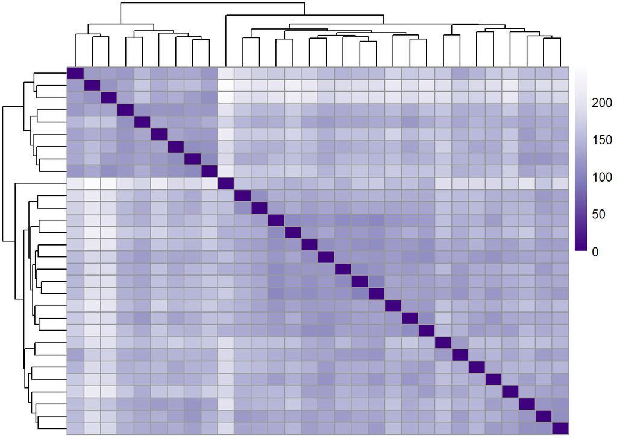

```r
library(pheatmap)
library(RColorBrewer)
rownames(sDistmatrix) <- paste( vsd$dex, vsd$cell, sep = " - " )
colnames(sDistmatrix) <- NULL
colors <- colorRampPalette( rev(brewer.pal(9, "Purples")) )(255)
pheatmap(sDistmatrix, clustering_distance_rows = sDist, clustering_distance_cols = sDist,col = colors)
```

*Figura 5: Distancias entre el número de tránscritos compartido por cada una de las muestras*

# Gráfico de análisis de componentes principales y de escalado multidimensional

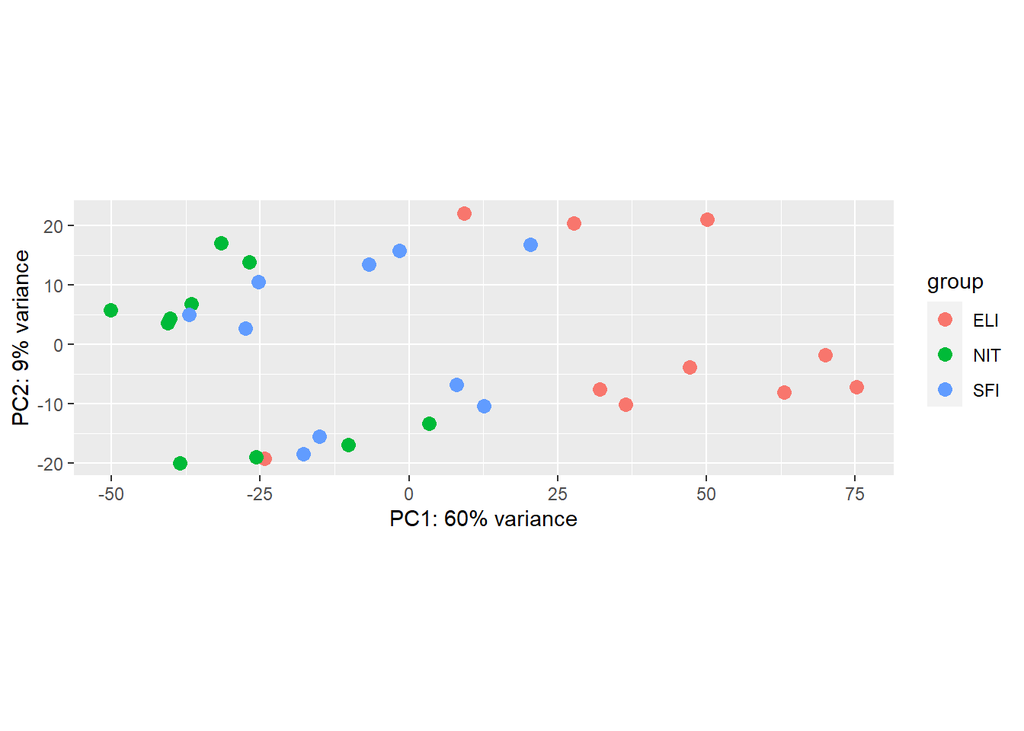

```r
library(DESeq2)
plotPCA(vsd, intgroup = c("Group"))
```

*Figura 6: Análisis de componentes principales por grupos de análisis*

El escalado multidimensional (MDS) es un medio para visualizar el nivel de similitud de casos individuales de un conjunto de datos. MDS se utiliza para traducir “información sobre las distancias por pares entre un conjunto de n objetos” en una configuración de n puntos mapeados en un espacio cartesiano abstracto.

Más técnicamente, MDS se refiere a un conjunto de técnicas de ordenación relacionadas utilizadas en la visualización de información, en particular para mostrar la información contenida en una matriz de distancia. Es una forma de reducción de dimensionalidad no lineal. Que aquí podemos usa para ver como se distribuyen los datos entre las distintas muestras.

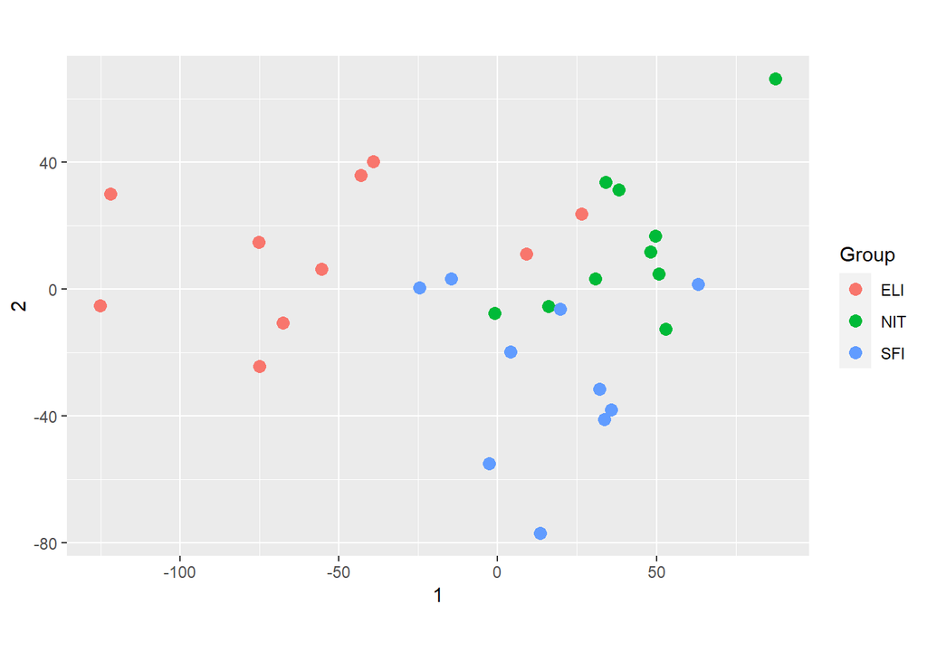

```r
library("dplyr")
library("ggplot2")
mds <- as.data.frame(colData(vsd))  %>% cbind(cmdscale(sDistmatrix))
ggplot(mds, aes(x = `1`, y = `2`, color = Group,)) + geom_point(size = 3) + coord_fixed()
```

*Figura 7: Análisis de escalado multidimensional*

Vemos que las muestras si se agrupan por grupos por lo que podemos entender que tienen unos perfiles de expresión que están pueden ser comparados.

# Análisis Diferencial de Expresión

A nuestro set de datos creado con `DESeqDataSeq` ya le hemos indicado que nuestras muestras se agrupan por grupos y que lo que queremos hacer es compararlas entre ellas. El paquete `DESeq` nos permite por tanto correr un análisis diferencial con un solo comando.

los datos de conteo generados por RNA-seq exhiben sobredispersión (varianza> media) y la distribución estadística utilizada para modelar los conteos necesita dar cuenta de esta sobredispersión.

```r
library(DESeq2)
ddsDE<- DESeq(dds)
```

El ajuste de modelos matemáticos es una manera de aproximar cómo se comportan los datos dado un conjunto de parámetros (es decir, factor de tamaño, dispersión). DESeq2 usará su fórmula como nuestro modelo para cada gen, y ajustará los datos de conteo normalizados. Después de que el modelo se ajuste, se calculan los coeficientes para cada grupo de muestras junto con su error estándar.

Nos devuelve un DESeqDataSet que contiene todos los parámetros ajustado, ahora vamos aextraer tablas de resultados de interés de este objeto. Debido a que Group`` es la única variable que estamos usando para hacer la comparativa de tres grupos distintos entre ellos. Es decir, nos interesa ver como se comparan los tres grupos de tejidos, los no inflitrados versus los que tienen pequeñas infiltraciones locales, y ambos dos contra los que están altamente infiltrados. Para ello podemos usar el comando de resultados de DESeq2:

```r
library(DESeq2)
#Primero comparamos ELI vs NIT
resEvN<- results(ddsDE, contrast = c("Group", "ELI", "NIT"))
knitr::kable(head(resEvN))
```

|  | baseMean | log2FoldChange | lfcSE | stat | pvalue | padj |
| --- | --- | --- | --- | --- | --- | --- |
| ENSG00000223972 | 2.932635 | -1.3508333 | 0.9623018 | -1.4037523 | 0.1603926 | 0.4516220 |
| ENSG00000227232 | 783.348750 | -0.1181932 | 0.2237991 | -0.5281220 | 0.5974147 | 0.8305886 |
| ENSG00000243485 | 1.279041 | -0.8705675 | 0.7863122 | -1.1071525 | 0.2682280 | 0.5795555 |
| ENSG00000237613 | 1.598541 | -1.7009702 | 0.8373087 | -2.0314733 | 0.0422070 | 0.2204136 |
| ENSG00000268020 | 0.959569 | -1.4293569 | 1.1017465 | -1.2973555 | 0.1945089 | 0.4976740 |
| ENSG00000240361 | 1.199737 | -0.9005568 | 0.9483620 | -0.9495918 | 0.3423197 | 0.6493541 |

```r
# Después ELI vs SFI
resEvS<- results(ddsDE, contrast = c("Group", "ELI", "SFI"))
knitr::kable(head(resEvS))
```

|  | baseMean | log2FoldChange | lfcSE | stat | pvalue | padj |
| --- | --- | --- | --- | --- | --- | --- |
| ENSG00000223972 | 2.932635 | -0.3996270 | 0.9802049 | -0.4076975 | 0.6834958 | 0.8398910 |
| ENSG00000227232 | 783.348750 | 0.1721448 | 0.2238491 | 0.7690216 | 0.4418805 | 0.6762841 |
| ENSG00000243485 | 1.279041 | -0.8255250 | 0.7768931 | -1.0625980 | 0.2879643 | NA |
| ENSG00000237613 | 1.598541 | -1.4321835 | 0.8406766 | -1.7036081 | 0.0884543 | 0.2638195 |
| ENSG00000268020 | 0.959569 | -0.5326270 | 1.1442556 | -0.4654790 | 0.6415885 | NA |
| ENSG00000240361 | 1.199737 | -1.4045464 | 0.9103158 | -1.5429221 | 0.1228497 | NA |

```r
#Por último, SFI vs NIT
resSvN<- results(ddsDE, contrast = c("Group", "SFI", "NIT"))
knitr::kable(head(resSvN))
```

|  | baseMean | log2FoldChange | lfcSE | stat | pvalue | padj |
| --- | --- | --- | --- | --- | --- | --- |
| ENSG00000223972 | 2.932635 | -0.9512063 | 0.9479772 | -1.0034062 | 0.3156649 | NA |
| ENSG00000227232 | 783.348750 | -0.2903380 | 0.2238672 | -1.2969205 | 0.1946586 | 0.5346115 |
| ENSG00000243485 | 1.279041 | -0.0450425 | 0.7182310 | -0.0627131 | 0.9499950 | NA |
| ENSG00000237613 | 1.598541 | -0.2687867 | 0.7209901 | -0.3728022 | 0.7092956 | NA |
| ENSG00000268020 | 0.959569 | -0.8967299 | 1.0564308 | -0.8488298 | 0.3959760 | NA |
| ENSG00000240361 | 1.199737 | 0.5039897 | 0.8436335 | 0.5974036 | 0.5502380 | NA |

Ahora debemos darle significado a estas comparaciones. Primero deberíamos decidir que cual es el ratio de falsos postivos que vamos a considerar aceptables. Para ello vamos primero a ver un resumen de las tres comparativas:

```r
summary(resEvN)
```

```
##
## out of 46263 with nonzero total read count
## adjusted p-value < 0.1
## LFC > 0 (up)       : 2895, 6.3%
## LFC < 0 (down)     : 957, 2.1%
## outliers [1]       : 0, 0%
## low counts [2]     : 15078, 33%
## (mean count < 1)
## [1] see 'cooksCutoff' argument of ?results
## [2] see 'independentFiltering' argument of ?results
```

```r
summary(resEvS)
```

```
##
## out of 46263 with nonzero total read count
## adjusted p-value < 0.1
## LFC > 0 (up)       : 3374, 7.3%
## LFC < 0 (down)     : 2220, 4.8%
## outliers [1]       : 0, 0%
## low counts [2]     : 16851, 36%
## (mean count < 1)
## [1] see 'cooksCutoff' argument of ?results
## [2] see 'independentFiltering' argument of ?results
```

```r
summary(resSvN)
```

```
##
## out of 46263 with nonzero total read count
## adjusted p-value < 0.1
## LFC > 0 (up)       : 615, 1.3%
## LFC < 0 (down)     : 508, 1.1%
## outliers [1]       : 0, 0%
## low counts [2]     : 21285, 46%
## (mean count < 4)
## [1] see 'cooksCutoff' argument of ?results
## [2] see 'independentFiltering' argument of ?results
```

Una gráfica que puede ser útil para explorar nuestros resultados es la gráfica MA. El gráfico MA muestra la media de los recuentos normalizados frente a los cambios de log2 para todos los genes probados. Los genes que son significativamente DE están coloreados para ser fácilmente identificados. Esta también es una excelente manera de ilustrar el efecto de la contracción de LFC. El paquete DESeq2 ofrece una función simple para generar un diagrama MA.

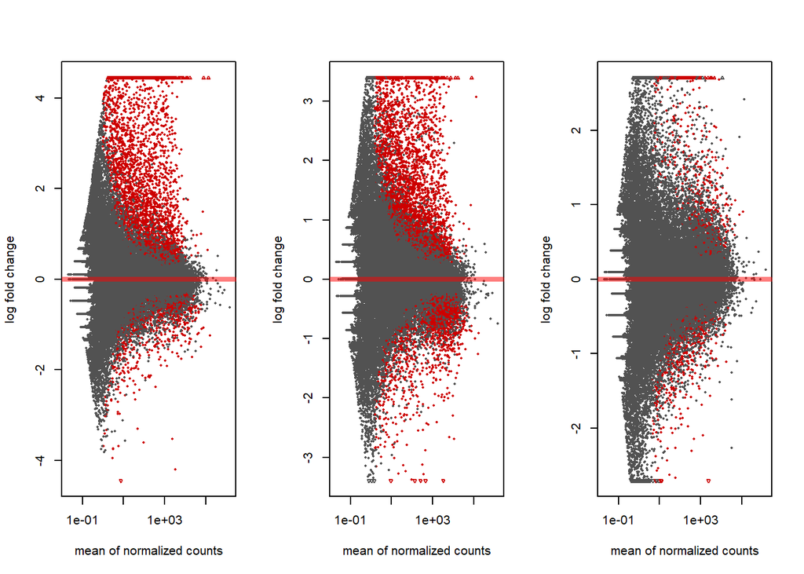

```r
library(DESeq2)
par(mfrow=c(1,3))
plotMA(resEvN)
plotMA(resEvS)
plotMA(resSvN)
```

Vamos a considerar que aceptamos un 5% de falsos positivos como aceptable. Por tanto podemos considerar todos los genes que sean considerados como significativos si tienen un p value ajustado por debajo de 0.05. Primero vamos a ver cuantos genes tenemos que cumplen estas condiciones para cada comparativa:

```r
sum(resEvN$padj < 0.05, na.rm = TRUE)
```

```
## [1] 2978
```

```r
sum(resEvS$padj < 0.05, na.rm = TRUE)
```

```
## [1] 3900
```

```r
sum(resSvN$padj < 0.05, na.rm = TRUE)
```

```
## [1] 452
```

Bien, vemos que tenemos un número aceptable de genes que cumplen esta restricción, por lo que ahora podemos reducir nuestra lista a únicamente aquellos tránscritos que sean significativos a un padj < 0.05

```r
sub_resEvN<- subset(resEvN, padj < 0.05)

sub_resEvS<- subset(resEvS, padj < 0.05)

sub_resSvN<- subset(resSvN, padj < 0.05)

head(sub_resEvN[order(sub_resEvN$log2FoldChange), ])
```

```
## log2 fold change (MLE): Group ELI vs NIT
## Wald test p-value: Group ELI vs NIT
## DataFrame with 6 rows and 6 columns
##                         baseMean    log2FoldChange             lfcSE
##                        <numeric>         <numeric>         <numeric>
## ENSG00000232400 7.26138071311974 -6.84316537426989  1.69506090527781
## ENSG00000110680 3211.23562720098 -4.20368360816403  1.37742717098002
## ENSG00000203635 2.86618329554164 -3.95249085705597  1.13586317977501
## ENSG00000243584  5.6785259742752 -3.68136505085594 0.992767530283344
## ENSG00000079689 97.3242363459897 -3.60094807462728  1.16120331974772
## ENSG00000125740 2333.40450406722 -3.52392337464611 0.877142891290658
##                              stat               pvalue                padj
##                         <numeric>            <numeric>           <numeric>
## ENSG00000232400 -4.03712064443391 5.41112452831122e-05 0.00129613472092505
## ENSG00000110680 -3.05183729254677  0.00227445352592808  0.0284873020534615
## ENSG00000203635 -3.47972443110522  0.00050192976932354 0.00853526920168662
## ENSG00000243584 -3.70818438210328 0.000208750638116855  0.0041309049181157
## ENSG00000079689 -3.10104872539428  0.00192836556150407  0.0251947787040752
## ENSG00000125740 -4.01750206224768 5.88183207745575e-05 0.00139072552691139
```

y para verlos en orden de más a menos expresados;

```r
head(sub_resEvN[ order(sub_resEvN$log2FoldChange, decreasing = TRUE),  ])
```

```
## log2 fold change (MLE): Group ELI vs NIT
## Wald test p-value: Group ELI vs NIT
## DataFrame with 6 rows and 6 columns
##                            baseMean   log2FoldChange            lfcSE
##                           <numeric>        <numeric>        <numeric>
## ENSG00000223350    166.561837835922 9.12886685361509 1.37312559403055
## ENSG00000211639    138.503334198054 8.99873307633086 1.67568484454352
## ENSG00000234184    32.0025861822028 8.84679697229805 1.34361550860299
## ENSG00000170054.10 35.4045336548187 8.75989012721371 1.38088991029972
## ENSG00000163518    26.6987102739709  8.3101149220612 1.04980406133632
## ENSG00000100721    230.841807281358 8.09868251567661 1.02555266754954
##                                stat               pvalue                 padj
##                           <numeric>            <numeric>            <numeric>
## ENSG00000223350    6.64823880153529 2.96620787214265e-11 4.92059175045281e-09
## ENSG00000211639    5.37018229032335 7.86570925683212e-08 4.84798171132062e-06
## ENSG00000234184    6.58432186563281 4.56966229101079e-11 7.09025163531112e-09
## ENSG00000170054.10 6.34365568310396 2.24376004578346e-10 2.94017414066592e-08
## ENSG00000163518    7.91587233095965 2.45525462514144e-15 1.66460926074535e-12
## ENSG00000100721    7.89689576355703   2.859353009162e-15  1.7834928459347e-12
```

# Visualización de los resultados

Una forma rápida de visualizar los recuentos de un gen en particular es usar la función plotCounts que toma como argumentos el DESeqDataSet

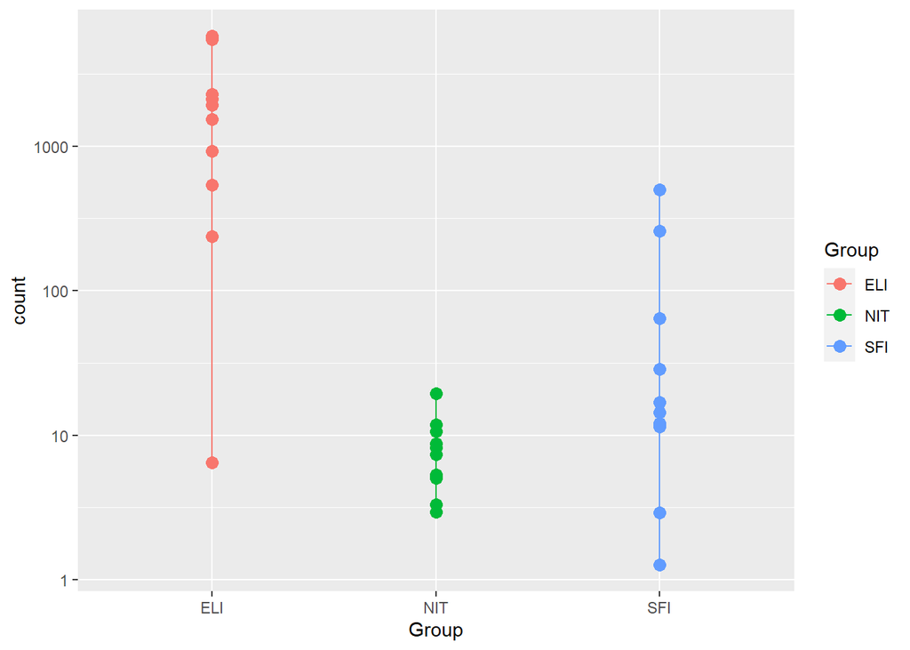

```r
topGene1 <- rownames(resEvN)[which.min(resEvN$padj)]
topGene2 <- rownames(resSvN)[which.min(resSvN$padj)]
topgene3<-rownames(resEvS)[which.min(resEvS$padj)]
library(ggbeeswarm)

geneCounts1 <- plotCounts(ddsDE, gene = topGene1, intgroup = c("Group"), returnData = TRUE)
geneCounts2 <- plotCounts(ddsDE, gene = topGene2, intgroup = c("Group"), returnData = TRUE)
geneCounts3 <- plotCounts(ddsDE, gene = topgene3, intgroup = c("Group"), returnData = TRUE)

par(mfrow=c(1,3))
ggplot(geneCounts1, aes(x = Group, y = count, color = Group, group = Group)) +
    scale_y_log10() + geom_point(size = 3) + geom_line()
```

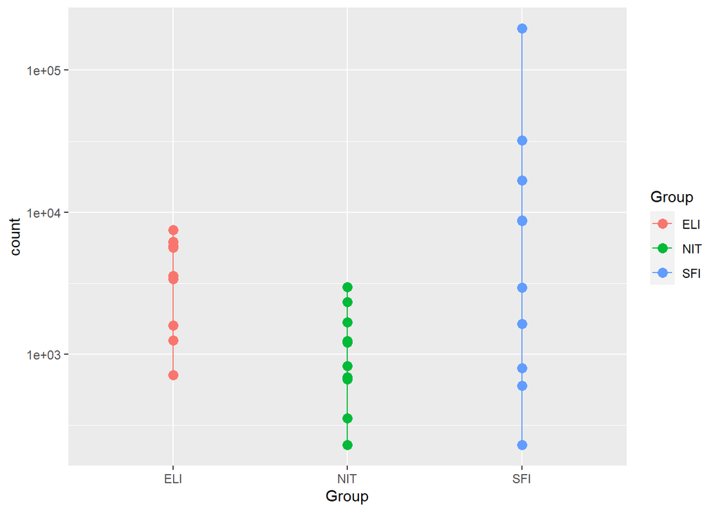

```r
ggplot(geneCounts2, aes(x = Group, y = count, color = Group, group = Group)) +
    scale_y_log10() + geom_point(size = 3) + geom_line()
```

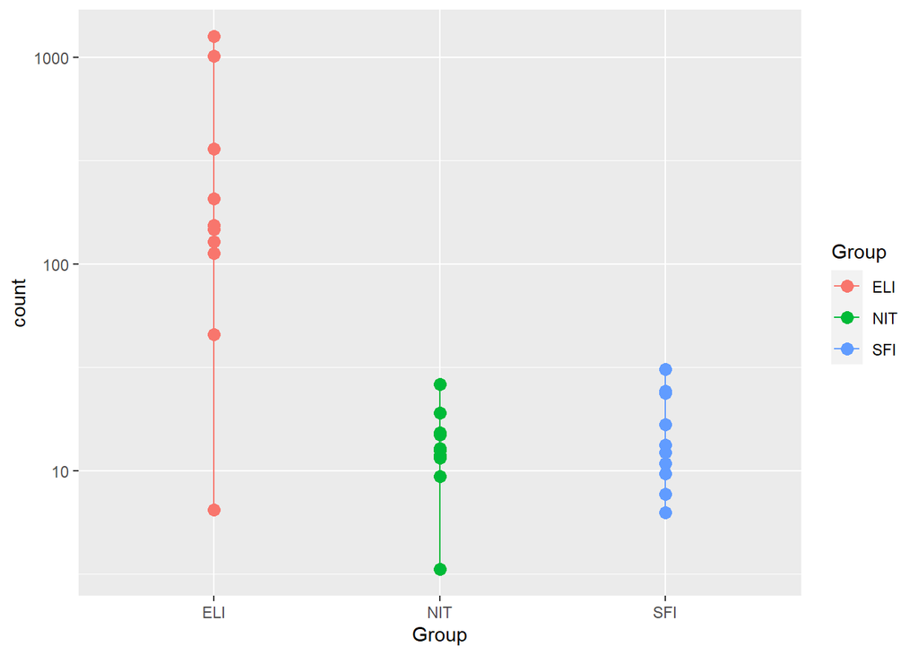

```r
ggplot(geneCounts3, aes(x = Group, y = count, color = Group, group = Group)) +
    scale_y_log10() + geom_point(size = 3) + geom_line()
```

Otra manera de ver cuanto varían los niveles de expresión de los genes es mediante un clustering de genes, en este caso al ser demasiado hacerlo con todos, lo vamos ahacer con 20 genes con más varianza entre todas las muestras. Se trabaja con los datos obtenidos del VST.

```r
library(DESeq2)
library(genefilter)
```

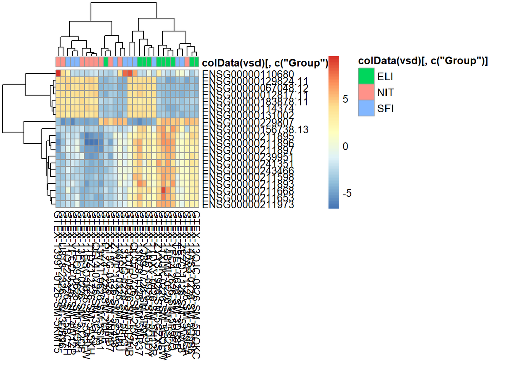

```r
library(pheatmap)

top1<- head(order(rowVars(assay(vsd)), decreasing= TRUE), 20)
mat <- assay(vsd)[top1, ]
mat <- mat - rowMeans(mat)
anno<-as.data.frame(colData(vsd)[, c("Group")],col.name=c("Group"))
rownames(anno)<-colnames(mat)
par(mar=c(1,1,1,1))
pheatmap(mat, annotation_col = anno)
```

*Figura 10: mapa de color entre la expresión de los genes en las distintas muestras*

# Anotar y exportar los datos

Ahora hay que convertir estos datos en tránscritos en valores reales de genes que estén anotados en la base de datos del genoma humano. Vamos a usar el hg19 como en el ejemplo visto en clase. Lo vamos a hacer sobre los resultados ya filtrados, para un padj de 0.05, ya que no nos interesan el resto de resultados de aquí en adelante

```r
library("AnnotationDbi")
library(org.Hs.eg.db)
```

```r
#para darle las anotaciones de los tránscritos de ENSEMBL
sub_resEvN$symbol <- mapIds(org.Hs.eg.db,keys=row.names(sub_resEvN),column="SYMBOL",keytype="ENSEMBL",multiVals="first")
sub_resEvS$symbol <- mapIds(org.Hs.eg.db,keys=row.names(sub_resEvS),column="SYMBOL",keytype="ENSEMBL",multiVals="first")
sub_resSvN$symbol<-mapIds(org.Hs.eg.db,keys=row.names(sub_resSvN),column="SYMBOL",keytype="ENSEMBL",multiVals="first")
#para darles las anotaciones de los genes de ENTREZID

sub_resEvN$entrez <- mapIds(org.Hs.eg.db,keys=row.names(sub_resEvN),column="ENTREZID",keytype="ENSEMBL",multiVals="first")
sub_resEvS$entrez<-mapIds(org.Hs.eg.db,keys=row.names(sub_resEvS),column="ENTREZID",keytype="ENSEMBL",multiVals="first")
sub_resSvN$entrez <- mapIds(org.Hs.eg.db,keys=row.names(sub_resSvN),column="ENTREZID",keytype="ENSEMBL",multiVals="first")
```

Podemos comprobar que efectivamente tenemos los transcritos anotados:

```r
head(sub_resEvN)
```

```
## log2 fold change (MLE): Group ELI vs NIT
## Wald test p-value: Group ELI vs NIT
## DataFrame with 6 rows and 8 columns
##                         baseMean     log2FoldChange             lfcSE
##                        <numeric>          <numeric>         <numeric>
## ENSG00000187583 133.669103146614   1.66997570767964 0.415191309694794
## ENSG00000187642 49.4375224881058   1.38157600665327 0.354272624570198
## ENSG00000188157 16263.6014302101 -0.572416836265337 0.186209130824437
## ENSG00000217801 143.604772669781   1.03732572187864 0.289606237163965
## ENSG00000223823 10.8017646682439   3.42329961240217 0.563158372263251
## ENSG00000186891 162.579120027104   3.53507177169181 0.495878800064349
##                              stat               pvalue                 padj
##                         <numeric>            <numeric>            <numeric>
## ENSG00000187583  4.02218367457459 5.76610644204813e-05  0.00137168239212933
## ENSG00000187642  3.89975377953459 9.62905611037303e-05  0.00212227118667282
## ENSG00000188157 -3.07405353180574   0.0021117153697594   0.0270113740041181
## ENSG00000217801  3.58184869233785 0.000341171381635356  0.00615747215223487
## ENSG00000223823  6.07875116664684 1.21122146512283e-09 1.26759610177134e-07
## ENSG00000186891  7.12890281099549 1.01172136580079e-12 2.46504329962728e-10
##                       symbol      entrez
##                  <character> <character>
## ENSG00000187583      PLEKHN1       84069
## ENSG00000187642        PERM1       84808
## ENSG00000188157         AGRN      375790
## ENSG00000217801 LOC100288175   100288175
## ENSG00000223823    LINC01342      254099
## ENSG00000186891     TNFRSF18        8784
```

Podemos ver que la anotación se ha realizado correctamente y que ahora tenemos dos nuevas columnas, una con el símbolo de ENSEMBL y otra con el código de ENTREZID.Ahora podemos exportarlos en formato csv para poder revisarlos fuera del ambiente R.

```r
 write.csv(sub_resEvN,"C:/Users/slezcano/Documents/Silvia/Omicas/PEC2_T3/EliVsNit.csv")
write.csv(sub_resEvS,"C:/Users/slezcano/Documents/Silvia/Omicas/PEC2_T3/ElivsSfi.csv")
write.csv(sub_resSvN,"C:/Users/slezcano/Documents/Silvia/Omicas/PEC2_T3/SfiVsNIT.csv")
```

También podemos convertirlos en reports html de manera que podamos visualizarlos y filtrarlos de una manera más cómoda e interactiva (Huntley, 2013).Para ello podemos usar el paquete `ReportingTools`

```r
library(ReportingTools)
EvNDF<-as.data.frame(sub_resEvN)
EvSDF<-as.data.frame(sub_resEvS)
SvNDF<-as.data.frame(sub_resSvN)

rep1<- HTMLReport(shortName = "rep1", title = "ELI vs NIT", reportDirectory = ".")
rep2<- HTMLReport(shortName = "rep2", title = "ELI vs SIF", reportDirectory = ".")
rep3<-HTMLReport(shortName = "rep3", title = "SIF vs NIT", reportDirectory = ".")

publish(EvNDF, rep1)
url<-finish(rep1)

publish(EvSDF, rep2)
url2<-finish(rep2)

publish(SvNDF, rep3)
url3<-finish(rep3)
```

Ahora podremos acceder a los archivos en formato HTML en el directorio de trabajo de los resultados.

# Eliminar efectos de Batch:

Podemos por último revisar los datos y ver si tenemos algun efecto debido al batch que deba ser corregido o tenido en cuenta. Podemos usar métodos estadísticos diseñados para RNA-seq del paquete sva (Leek 2014) en Bioconductor para detectar tales agrupaciones de muestras, y luego podemos agregarlas al diseño DESeqDataSet, para tenerlas en cuenta.

El paquete sva contiene funciones para eliminar efectos por batch y otras variaciones no deseadas en experimentos de alto rendimiento como es el caso de RNAseq. Específicamente, el paquete sva contiene funciones para identificar y construir variables sustitutas para conjuntos de datos. Las variables sustitutas son covariables construidas directamente a partir de los datos que puede usarse en análisis posteriores para ajustar fuentes de ruido desconocidas.

Como conocemos los datos sabemos que se tienen que agrupar correctamente en tres grupos distintos, y podemos ver visualmente como se agrupan en función a dos variables surrogadas:

```r
library(sva)
dat<-counts(ddsDE, normalize=TRUE)
idx  <- rowMeans(dat) > 1
dat  <- dat[idx, ]
mod  <- model.matrix(~ Group, colData(dds))
mod0 <- model.matrix(~   1, colData(dds))
svseq <- svaseq(dat, mod, mod0, n.sv = 2)
```

```
## Number of significant surrogate variables is:  2
## Iteration (out of 5 ):1  2  3  4  5
```

```r
svseq$sv
```

```
##               [,1]         [,2]
##  [1,]  0.010948826 -0.075314204
##  [2,] -0.137944269 -0.278396157
##  [3,] -0.234134039  0.094802003
##  [4,] -0.065969278  0.254370343
##  [5,] -0.382997076 -0.235400126
##  [6,] -0.345245013 -0.034189418
##  [7,] -0.149949708  0.069557826
##  [8,] -0.088171123 -0.034421382
##  [9,] -0.188552528 -0.159250185
## [10,]  0.145900584  0.298340211
## [11,]  0.097885622 -0.176622513
## [12,]  0.098269557  0.356242915
## [13,] -0.078015237 -0.143556938
## [14,]  0.173602965  0.045103684
```

[output cut: 16 more lines]

Como realmente conocemos el grupo al que pertence cada muestra podemos hacer un gráfico para ver como ha conseguido el método SVA hacer el agrupamiento

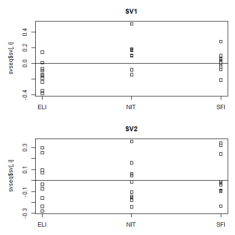

*Figura 12:Control de efectos de batch vía SVA*

```r
png("png1.png")
par(mfrow = c(2, 1), mar=c(3,5,3,1))
 for (i in 1:2) {
     stripchart(svseq$sv[, i] ~ dds$Group, vertical = TRUE, main = paste0("SV", i))
     abline(h = 0)
 }
dev.off()
```

RUV propone una estrategia de normalización, llamada “eliminar la variación no deseada” (RUV), que se ajusta a los efectos técnicos que pueden generar un problema mediante el análisis factorial en conjuntos de genes de control (por ejemplo, spike-in de ERCC) o muestras replicadas. Su enfoque conduce a estimaciones más precisas de los cambios de expresión y pruebas de expresión diferencial en comparación otros métodos de normalización. En particular, RUV se recomienda en grandes proyectos de colaboración que involucren múltiples laboratorios, técnicos y / o plataformas de secuenciación. Para normalizar toda esa variabilidad que se produce por puros efectos técnicos.

# Conclusiones

En este trabajo hemos explorado una posible pipeline de análisis de datos de RNASeq, una vez obtenido los datos de los genes expresados de manera diferencial entre las tres condiciones con un p-valor ajustado menor o igual a 0.05 deberá luego ser interpretado, es decir, los biólogos y ciéntificos tendrán que evaluar cuales de los genes obtenidos en este estudio pueden tener un signficado biológico para explicar nuestra hipótesis. Para ello podrán utilizar nuestro output anotado, nuestros csv o reports html que les permitirán ver los genes afectados de una manera más senciall.

En este ejemplo, este análisis serviría para, al ser interpretado, entender mejor a biología de los tejidos sin infiltración, con un poco de infiltración y con infiltración alta por parte de algún otro tipo de células que no son las del tiroides (no se especifica). Ver que genes están sobre expresados o inhibidos en los tejidos infiltrados versus los no infiltrados ayudaría a enteneder cual es el mecanismo por el cual se produce la infiltración en las células estudiadas.

# Referencias

http://bioconductor.org/packages/devel/bioc/vignettes/DESeq2/inst/doc/DESeq2.html#standard-workflow

Love, M.I., Huber, W., Anders, S. (2014) Moderated estimation of fold change and dispersion for RNA-seq data with DESeq2. Genome Biology, 15:550. 10.1186/s13059-014-0550-8

Anders S, Huber W. Differential expression analysis for sequence count data. Genome Biol. 2010;11(10):R106. doi:10.1186/gb-2010-11-10-r106

Huntley MA, Larson JL, Chaivorapol C, Becker G, Lawrence M, Hackney JA, Kaminker JS (in press). “ReportingTools: an automated result processing and presentation toolkit for high throughput genomic analyses.” Bioinformatics. (2013)

Risso D, Ngai J, Speed T, Dudoit S (2014). “Normalization of RNA-seq data using factor analysis of control genes or samples.” Nature Biotechnology, 32(9), 896–902.

Leek JT, Johnson WE, Parker HS, Fertig EJ, Jaffe AE, Zhang Y, Storey JD, Torres LC (2020). sva: Surrogate Variable Analysis